# NetFlix_ANALYSIS

### Netflix Analysis

```python
import pandas as pd
import matplotlib.pyplot as plt
import seaborn as sns
import numpy as np
```

```python
data=pd.read_csv("mymoviedb.csv",lineterminator='\n')
```

```python
data.head()
```

|  | Release_Date | Title | Overview | Popularity | Vote_Count | Vote_Average | Original_Language | Genre | Poster_Url |
| --- | --- | --- | --- | --- | --- | --- | --- | --- | --- |
| 0 | 2021-12-15 | Spider-Man: No Way Home | Peter Parker is unmasked and no longer able to... | 5083.954 | 8940 | 8.3 | en | Action, Adventure, Science Fiction | https://image.tmdb.org/t/p/original/1g0dhYtq4i... |
| 1 | 2022-03-01 | The Batman | In his second year of fighting crime, Batman u... | 3827.658 | 1151 | 8.1 | en | Crime, Mystery, Thriller | https://image.tmdb.org/t/p/original/74xTEgt7R3... |
| 2 | 2022-02-25 | No Exit | Stranded at a rest stop in the mountains durin... | 2618.087 | 122 | 6.3 | en | Thriller | https://image.tmdb.org/t/p/original/vDHsLnOWKl... |
| 3 | 2021-11-24 | Encanto | The tale of an extraordinary family, the Madri... | 2402.201 | 5076 | 7.7 | en | Animation, Comedy, Family, Fantasy | https://image.tmdb.org/t/p/original/4j0PNHkMr5... |
| 4 | 2021-12-22 | The King's Man | As a collection of history's worst tyrants and... | 1895.511 | 1793 | 7.0 | en | Action, Adventure, Thriller, War | https://image.tmdb.org/t/p/original/aq4Pwv5Xeu... |

```python
data.info()
```

```
<class 'pandas.core.frame.DataFrame'>
RangeIndex: 9827 entries, 0 to 9826
Data columns (total 9 columns):
 #   Column             Non-Null Count  Dtype
---  ------             --------------  -----
 0   Release_Date       9827 non-null   object
 1   Title              9827 non-null   object
 2   Overview           9827 non-null   object
 3   Popularity         9827 non-null   float64
 4   Vote_Count         9827 non-null   int64
 5   Vote_Average       9827 non-null   float64
 6   Original_Language  9827 non-null   object
 7   Genre              9827 non-null   object
 8   Poster_Url         9827 non-null   object
dtypes: float64(2), int64(1), object(6)
memory usage: 691.1+ KB
```

```python
data.isnull().sum()
```

```
Release_Date         0
Title                0
Overview             0
Popularity           0
Vote_Count           0
Vote_Average         0
Original_Language    0
Genre                0
Poster_Url           0
dtype: int64
```

looks like there is no missing values in the datasets

```python
data['Genre'].head()
```

```
0    Action, Adventure, Science Fiction
1              Crime, Mystery, Thriller
2                              Thriller
3    Animation, Comedy, Family, Fantasy
4      Action, Adventure, Thriller, War
Name: Genre, dtype: object
```

```python
data.duplicated().sum()
```

```
0
```

Dataset has no duplicated values

```python
data.describe()
```

|  | Popularity | Vote_Count | Vote_Average |
| --- | --- | --- | --- |
| count | 9827.000000 | 9827.000000 | 9827.000000 |
| mean | 40.326088 | 1392.805536 | 6.439534 |
| std | 108.873998 | 2611.206907 | 1.129759 |
| min | 13.354000 | 0.000000 | 0.000000 |
| 25% | 16.128500 | 146.000000 | 5.900000 |
| 50% | 21.199000 | 444.000000 | 6.500000 |
| 75% | 35.191500 | 1376.000000 | 7.100000 |
| max | 5083.954000 | 31077.000000 | 10.000000 |

# Summary Statistics

we have datasets consisting of 9827 rows, and there is no missing values and duplicate values. we need to work on Release date beacuse its data type should convert to datetime. Genre column has some space betwwen value which we should clean before start the analysis.

```python
data['Release_Date']=pd.to_datetime(data['Release_Date'])
print(data['Release_Date'].dtypes)
```

```
datetime64[ns]
```

```python
data['Release_Date']=data['Release_Date'].dt.year
data['Release_Date'].dtypes
```

```
dtype('int32')
```

```python
data.head()
```

|  | Release_Date | Title | Overview | Popularity | Vote_Count | Vote_Average | Original_Language | Genre | Poster_Url |
| --- | --- | --- | --- | --- | --- | --- | --- | --- | --- |
| 0 | 2021 | Spider-Man: No Way Home | Peter Parker is unmasked and no longer able to... | 5083.954 | 8940 | 8.3 | en | Action, Adventure, Science Fiction | https://image.tmdb.org/t/p/original/1g0dhYtq4i... |
| 1 | 2022 | The Batman | In his second year of fighting crime, Batman u... | 3827.658 | 1151 | 8.1 | en | Crime, Mystery, Thriller | https://image.tmdb.org/t/p/original/74xTEgt7R3... |
| 2 | 2022 | No Exit | Stranded at a rest stop in the mountains durin... | 2618.087 | 122 | 6.3 | en | Thriller | https://image.tmdb.org/t/p/original/vDHsLnOWKl... |
| 3 | 2021 | Encanto | The tale of an extraordinary family, the Madri... | 2402.201 | 5076 | 7.7 | en | Animation, Comedy, Family, Fantasy | https://image.tmdb.org/t/p/original/4j0PNHkMr5... |
| 4 | 2021 | The King's Man | As a collection of history's worst tyrants and... | 1895.511 | 1793 | 7.0 | en | Action, Adventure, Thriller, War | https://image.tmdb.org/t/p/original/aq4Pwv5Xeu... |

```python
cols=['Overview','Original_Language','Poster_Url']
```

```python
data.drop(cols,axis=1,inplace=True)
```

```python
data.head()
```

|  | Release_Date | Title | Popularity | Vote_Count | Vote_Average | Genre |
| --- | --- | --- | --- | --- | --- | --- |
| 0 | 2021 | Spider-Man: No Way Home | 5083.954 | 8940 | 8.3 | Action, Adventure, Science Fiction |
| 1 | 2022 | The Batman | 3827.658 | 1151 | 8.1 | Crime, Mystery, Thriller |
| 2 | 2022 | No Exit | 2618.087 | 122 | 6.3 | Thriller |
| 3 | 2021 | Encanto | 2402.201 | 5076 | 7.7 | Animation, Comedy, Family, Fantasy |
| 4 | 2021 | The King's Man | 1895.511 | 1793 | 7.0 | Action, Adventure, Thriller, War |

```python
def catigorize_col(data,col,labels):
    edges=[data[col].describe()['min'],
           data[col].describe()['25%'],
           data[col].describe()['50%'],
           data[col].describe()['75%'],
           data[col].describe()['max']]
    data[col]=pd.cut(data[col],edges,labels=labels,duplicates='drop')
    return data
```

```python
labels=['not_popular','below_avg','average','popular']

catigorize_col(data,'Vote_Average',labels)

data['Vote_Average'].unique()
```

```
['popular', 'below_avg', 'average', 'not_popular', NaN]
Categories (4, object): ['not_popular' < 'below_avg' < 'average' < 'popular']
```

```python
data.head()
```

|  | Release_Date | Title | Popularity | Vote_Count | Vote_Average | Genre |
| --- | --- | --- | --- | --- | --- | --- |
| 0 | 2021 | Spider-Man: No Way Home | 5083.954 | 8940 | popular | Action, Adventure, Science Fiction |
| 1 | 2022 | The Batman | 3827.658 | 1151 | popular | Crime, Mystery, Thriller |
| 2 | 2022 | No Exit | 2618.087 | 122 | below_avg | Thriller |
| 3 | 2021 | Encanto | 2402.201 | 5076 | popular | Animation, Comedy, Family, Fantasy |
| 4 | 2021 | The King's Man | 1895.511 | 1793 | average | Action, Adventure, Thriller, War |

```python
data['Vote_Average'].value_counts()
```

```
Vote_Average
not_popular    2467
popular        2450
average        2412
below_avg      2398
Name: count, dtype: int64
```

```python
data['Genre']=data['Genre'].str.split(', ')
data=data.explode('Genre').reset_index(drop=True)
data.head()
```

|  | Release_Date | Title | Popularity | Vote_Count | Vote_Average | Genre |
| --- | --- | --- | --- | --- | --- | --- |
| 0 | 2021 | Spider-Man: No Way Home | 5083.954 | 8940 | popular | Action |
| 1 | 2021 | Spider-Man: No Way Home | 5083.954 | 8940 | popular | Adventure |
| 2 | 2021 | Spider-Man: No Way Home | 5083.954 | 8940 | popular | Science Fiction |
| 3 | 2022 | The Batman | 3827.658 | 1151 | popular | Crime |
| 4 | 2022 | The Batman | 3827.658 | 1151 | popular | Mystery |

```python
#Cating the column into category
data['Genre']=data['Genre'].astype('category')
data['Genre'].dtypes
```

```
CategoricalDtype(categories=['Action', 'Adventure', 'Animation', 'Comedy', 'Crime',
                  'Documentary', 'Drama', 'Family', 'Fantasy', 'History',
                  'Horror', 'Music', 'Mystery', 'Romance', 'Science Fiction',
                  'TV Movie', 'Thriller', 'War', 'Western'],
, ordered=False, categories_dtype=object)
```

```python
data.info()
```

```
<class 'pandas.core.frame.DataFrame'>
RangeIndex: 25793 entries, 0 to 25792
Data columns (total 6 columns):
 #   Column        Non-Null Count  Dtype
---  ------        --------------  -----
 0   Release_Date  25793 non-null  int32
 1   Title         25793 non-null  object
 2   Popularity    25793 non-null  float64
 3   Vote_Count    25793 non-null  int64
 4   Vote_Average  25552 non-null  category
 5   Genre         25793 non-null  category
dtypes: category(2), float64(1), int32(1), int64(1), object(1)
memory usage: 756.7+ KB
```

```python
data.nunique()
```

```
Release_Date     102
Title           9513
Popularity      8160
Vote_Count      3266
Vote_Average       4
Genre             19
dtype: int64
```

```python
data.head()
```

|  | Release_Date | Title | Popularity | Vote_Count | Vote_Average | Genre |
| --- | --- | --- | --- | --- | --- | --- |
| 0 | 2021 | Spider-Man: No Way Home | 5083.954 | 8940 | popular | Action |
| 1 | 2021 | Spider-Man: No Way Home | 5083.954 | 8940 | popular | Adventure |
| 2 | 2021 | Spider-Man: No Way Home | 5083.954 | 8940 | popular | Science Fiction |
| 3 | 2022 | The Batman | 3827.658 | 1151 | popular | Crime |
| 4 | 2022 | The Batman | 3827.658 | 1151 | popular | Mystery |

```python
sns.set_style('whitegrid')
```

1. what is the most frequent genre of movies released on Netflix

```python
data['Genre'].describe()
```

```
count     25793
unique       19
top       Drama
freq       3744
Name: Genre, dtype: object
```

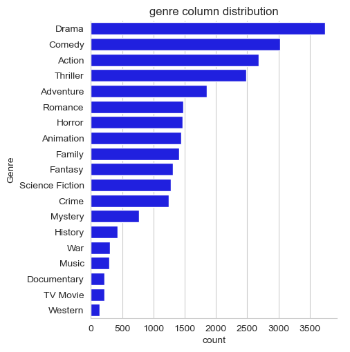

```python
sns.catplot(y='Genre',data=data,kind='count',
            order=data['Genre'].value_counts().index,
            color='blue')
plt.title("genre column distribution")
plt.show()
```

we can see Drama is the highest or most frequent genre in the dataset. SO netflix has taken Drama and comedy movies more. But netflix has less intrest in Documentary and western shows

## 2. which has highest votes in vote avg column

```python
data.head()
```

|  | Release_Date | Title | Popularity | Vote_Count | Vote_Average | Genre |
| --- | --- | --- | --- | --- | --- | --- |
| 0 | 2021 | Spider-Man: No Way Home | 5083.954 | 8940 | popular | Action |
| 1 | 2021 | Spider-Man: No Way Home | 5083.954 | 8940 | popular | Adventure |
| 2 | 2021 | Spider-Man: No Way Home | 5083.954 | 8940 | popular | Science Fiction |
| 3 | 2022 | The Batman | 3827.658 | 1151 | popular | Crime |
| 4 | 2022 | The Batman | 3827.658 | 1151 | popular | Mystery |

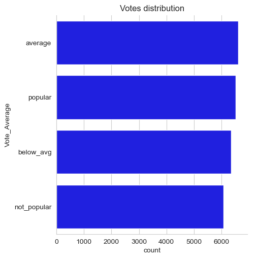

```python
sns.catplot(y='Vote_Average',kind='count',data=data,
            order=data['Vote_Average'].value_counts().index,
            color='blue')
plt.title("Votes distribution")
plt.show()
```

## 3. what movie ot yhe highest popularity and what's its genre.

```python
data[data['Popularity']==data['Popularity'].max()]
```

|  | Release_Date | Title | Popularity | Vote_Count | Vote_Average | Genre |
| --- | --- | --- | --- | --- | --- | --- |
| 0 | 2021 | Spider-Man: No Way Home | 5083.954 | 8940 | popular | Action |
| 1 | 2021 | Spider-Man: No Way Home | 5083.954 | 8940 | popular | Adventure |
| 2 | 2021 | Spider-Man: No Way Home | 5083.954 | 8940 | popular | Science Fiction |

Spider-Man :No way Home Movie which released in 2021 has the highest popularity in Netflix which is kind a Action Adventure Science fiction Genre.

## 4. What movie got the lowest popularity and wgats its genre

```python
data[data['Popularity']==data['Popularity'].min()]
```

|  | Release_Date | Title | Popularity | Vote_Count | Vote_Average | Genre |
| --- | --- | --- | --- | --- | --- | --- |
| 25787 | 2021 | The United States vs. Billie Holiday | 13.354 | 152 | average | Music |
| 25788 | 2021 | The United States vs. Billie Holiday | 13.354 | 152 | average | Drama |
| 25789 | 2021 | The United States vs. Billie Holiday | 13.354 | 152 | average | History |
| 25790 | 1984 | Threads | 13.354 | 186 | popular | War |
| 25791 | 1984 | Threads | 13.354 | 186 | popular | Drama |
| 25792 | 1984 | Threads | 13.354 | 186 | popular | Science Fiction |

The United states vs Billie Holiday has less popularity in Netflix

## 5. Which year has the highest filmed Movies

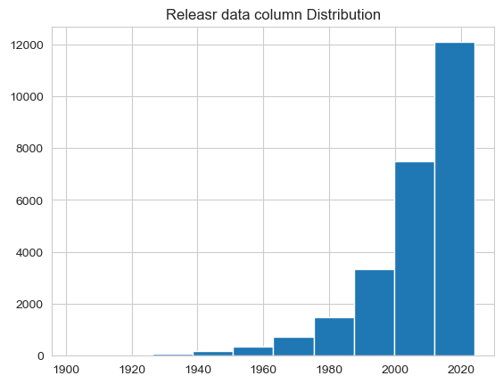

```python
data['Release_Date'].hist()
plt.title("Releasr data column Distribution")
plt.show()
```

6. Which genre has the highest average popularity?

```python
import warnings
warnings.filterwarnings('ignore')
```

```python
data.groupby('Genre')['Popularity'].mean().sort_values(ascending=False)
```

```
Genre
Adventure          53.742888
Fantasy            53.081342
Animation          52.433848
Action             50.890133
Science Fiction    49.511334
Family             46.610616
Crime              44.747295
Thriller           42.946258
Mystery            40.093590
Horror             38.264498
Comedy             37.873669
Western            36.187912
War                35.298075
Music              33.771410
Romance            30.866030
Drama              30.077651
TV Movie           29.954715
Documentary        29.235377
History            28.395827
Name: Popularity, dtype: float64
```

In netflix most freqently released movie Genre are Drama and comedy actions But the popularity is More in Adventure,Fantasy,Animations. Surprsingly drama, comedy are not in a top 10. Netflix should see this in future Years.

7. How has the number of movies released per year changed over time?

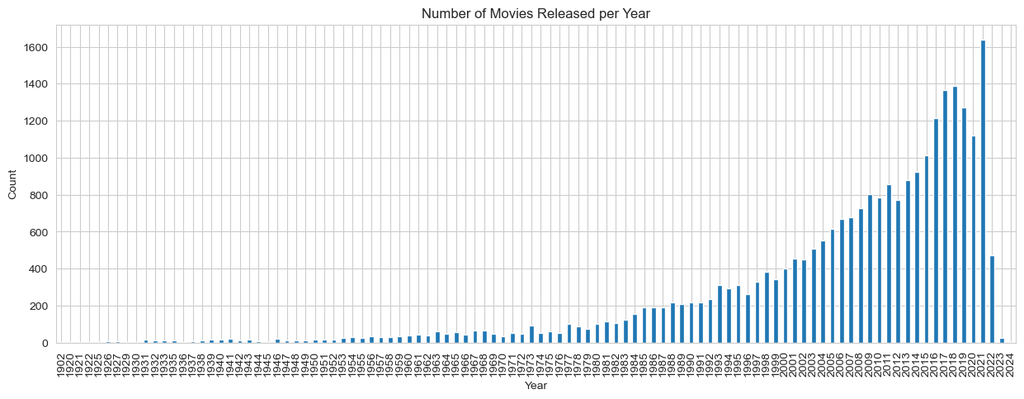

```python
data['Release_Date'].value_counts().sort_index().plot(kind='bar', figsize=(15,5))
plt.title('Number of Movies Released per Year')
plt.xlabel('Year')
plt.ylabel('Count')
plt.show()
```

8.Top 10 Most Popular Movies

```
                      Title  Popularity
0   Spider-Man: No Way Home    5083.954
3                The Batman    3827.658
6                   No Exit    2618.087
7                   Encanto    2402.201
11           The King's Man    1895.511
15             The Commando    1750.484
18                   Scream    1675.161
21                     Kimi    1601.782
22     Fistful of Vengeance    1594.013
25                 Eternals    1537.406
```

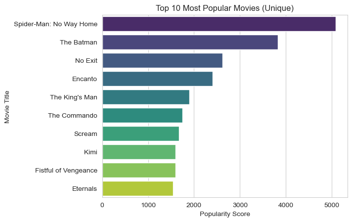

```python
data_unique = data.drop_duplicates(subset='Title', keep='first')
top_movies = data_unique[['Title', 'Popularity']].sort_values(by='Popularity', ascending=False).head(10)
print(top_movies)

sns.barplot(data=top_movies, x='Popularity', y='Title', palette='viridis')
plt.title('Top 10 Most Popular Movies (Unique)')
plt.xlabel('Popularity Score')
plt.ylabel('Movie Title')
plt.show()
```

9.Do multi-genre movies attract more viewers?

```python
genre_count = data.groupby('Title')['Genre'].count().reset_index()
genre_count.columns = ['Title', 'Genre_Count']

popularity_data = data[['Title', 'Popularity']].drop_duplicates()
genre_pop = pd.merge(genre_count, popularity_data, on='Title')

single_genre_avg = genre_pop[genre_pop['Genre_Count'] == 1]['Popularity'].mean()
multi_genre_avg = genre_pop[genre_pop['Genre_Count'] > 1]['Popularity'].mean()

print(f"Average Popularity - Single Genre: {single_genre_avg:.2f}")
print(f"Average Popularity - Multi Genre: {multi_genre_avg:.2f}")
```

```
Average Popularity - Single Genre: 37.33
Average Popularity - Multi Genre: 40.88
```

Multiple Genre has more good popularity than Single Genre

10.Analyze how many movies of each genre are released every year.

```python
yearly_genre = data.groupby(['Release_Date', 'Genre'])['Title'].nunique().reset_index()
yearly_genre.columns = ['Year', 'Genre', 'Movie_Count']

yearly_genre_table = yearly_genre.pivot(index='Year', columns='Genre', values='Movie_Count').fillna(0).astype(int)

yearly_genre_table
```

| Genre Year | Action | Adventure | Animation | Comedy | Crime | Documentary | Drama | Family | Fantasy | History | Horror | Music | Mystery | Romance | Science Fiction | TV Movie | Thriller | War | Western |
| --- | --- | --- | --- | --- | --- | --- | --- | --- | --- | --- | --- | --- | --- | --- | --- | --- | --- | --- | --- |
| 1902 | 0 | 1 | 0 | 0 | 0 | 0 | 0 | 0 | 1 | 0 | 0 | 0 | 0 | 0 | 1 | 0 | 0 | 0 | 0 |
| 1920 | 0 | 0 | 0 | 0 | 1 | 0 | 1 | 0 | 0 | 0 | 1 | 0 | 0 | 0 | 0 | 0 | 1 | 0 | 0 |
| 1921 | 0 | 0 | 0 | 1 | 0 | 0 | 2 | 0 | 1 | 0 | 1 | 0 | 0 | 0 | 0 | 0 | 0 | 0 | 0 |
| 1922 | 0 | 0 | 0 | 0 | 0 | 1 | 0 | 0 | 1 | 1 | 2 | 0 | 0 | 0 | 0 | 0 | 0 | 0 | 0 |
| 1925 | 0 | 0 | 0 | 0 | 0 | 0 | 1 | 0 | 0 | 1 | 0 | 0 | 0 | 0 | 0 | 0 | 0 | 0 | 0 |
| ... | ... | ... | ... | ... | ... | ... | ... | ... | ... | ... | ... | ... | ... | ... | ... | ... | ... | ... | ... |
| 2020 | 91 | 68 | 76 | 115 | 36 | 22 | 148 | 69 | 67 | 19 | 107 | 22 | 35 | 58 | 57 | 8 | 109 | 10 | 2 |
| 2021 | 133 | 75 | 94 | 196 | 89 | 46 | 262 | 81 | 73 | 29 | 110 | 30 | 46 | 84 | 63 | 20 | 181 | 15 | 9 |
| 2022 | 52 | 27 | 22 | 59 | 23 | 21 | 61 | 16 | 18 | 6 | 26 | 8 | 17 | 32 | 21 | 5 | 53 | 2 | 2 |
| 2023 | 6 | 7 | 0 | 2 | 1 | 0 | 1 | 1 | 3 | 0 | 0 | 0 | 0 | 1 | 5 | 0 | 0 | 0 | 0 |
| 2024 | 0 | 1 | 1 | 1 | 0 | 0 | 0 | 1 | 0 | 0 | 0 | 0 | 0 | 0 | 0 | 0 | 0 | 0 | 0 |

102 rows × 19 columns

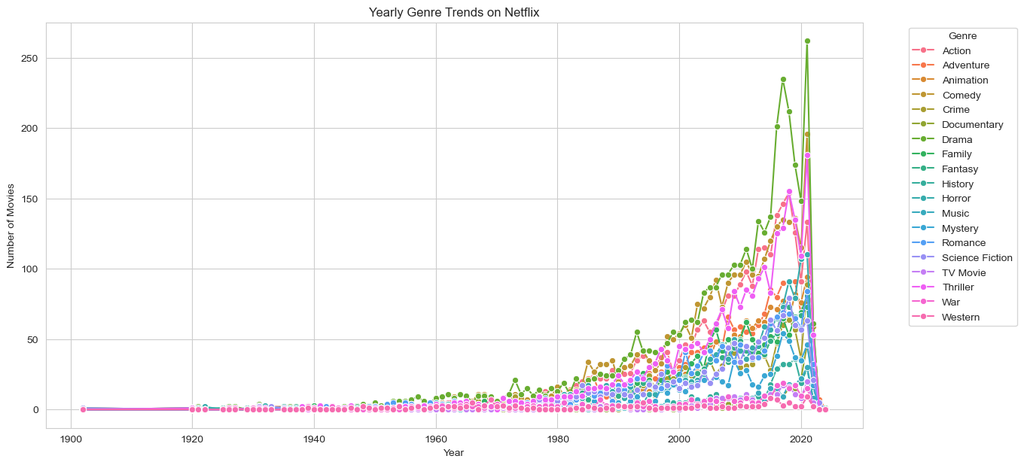

```python
# Plot trends
plt.figure(figsize=(14,7))
sns.lineplot(data=yearly_genre, x='Year', y='Movie_Count', hue='Genre', marker='o')
plt.title("Yearly Genre Trends on Netflix")
plt.xlabel("Year")
plt.ylabel("Number of Movies")
plt.legend(title='Genre', bbox_to_anchor=(1.05, 1))
plt.show()
```